# R Notebook

1. Estadística Descriptiva:  
   El análisis previo al desarrollo del modelo comenzó por revisar la estadística descriptiva de la base de datos, empezando de manera primitiva por contar y hacer una especie de censo, con el fin de vislumbrar las características de la base de datos

```r
count(meds,smoker)#atributo tipo nominal
```

| smoker | n |
| --- | --- |
| no | 2208 |
| yes | 564 |

```r
NA
```

```r
count(meds,sex)#atributo tipo nominal
```

| sex | n |
| --- | --- |
| female | 1366 |
| male | 1406 |

De aquí es posible ver que 1366 de las personas de la BD son mujeres, mientras que 1406 son hombres

```r
count(meds,region)#atributo tipo nominal
```

| region | n |
| --- | --- |
| northeast | 658 |
| northwest | 664 |
| southeast | 766 |
| southwest | 684 |

```r
NA
```

Por otro lado, podemos ver que la región de la que provienen las personas están distribuidas de manera prácticamente homogénea, con una mayoría de los encuestados provenientes de la sona sureste de los Estados Unidos.

El análisis prosigue con el estudio mediante gráficos de las carácterísticas de los encuestados, comenzando con un histograma de los Índices de masa corporal, un histograma de los costos de seguro médico.

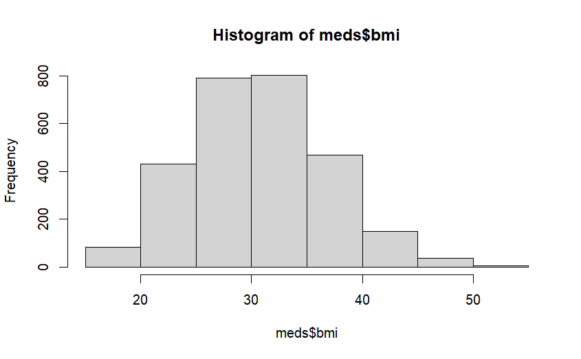

```r
hist(meds$bmi)
```

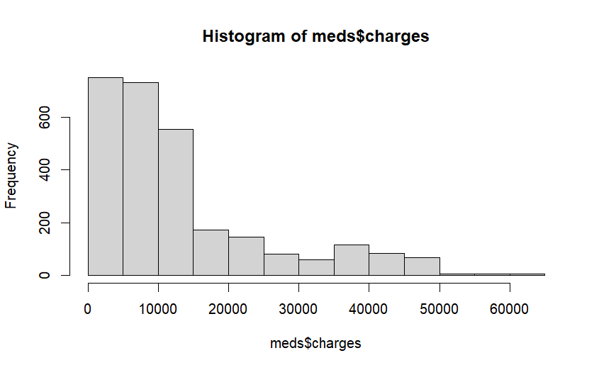

```r
hist(meds$charges)
```

Luego, se procedió a hacer agrupaciones que se estimaron convenientes y a calcular medidas de tendencia central para grupos de interés, partiendo por el cálculo de medias.

```r
meds |>
  group_by(smoker) |>
  summarize(across(everything(), mean))
```

| smoker | age | sex | bmi | children | region | charges |
| --- | --- | --- | --- | --- | --- | --- |
| no | 39.27536 | NA | 30.66577 | 1.097826 | NA | 8417.874 |
| yes | 38.46099 | NA | 30.84066 | 1.117021 | NA | 32223.140 |

```r
meds |>
  group_by(region) |>
  summarize(across(everything(), mean))
```

| region | age | sex | bmi | children | smoker | charges |
| --- | --- | --- | --- | --- | --- | --- |
| northeast | 39.24316 | NA | 29.15778 | 1.051672 | NA | 13475.87 |
| northwest | 39.08133 | NA | 29.14726 | 1.165663 | NA | 12463.13 |
| southeast | 38.76240 | NA | 33.47877 | 1.041775 | NA | 14748.78 |
| southwest | 39.39766 | NA | 30.58450 | 1.154971 | NA | 12164.20 |

```r
meds |>
  group_by(sex) |>
  summarize(across(everything(), mean))
```

| sex | age | bmi | children | smoker | region | charges |
| --- | --- | --- | --- | --- | --- | --- |
| female | 39.48170 | 30.43447 | 1.081991 | NA | NA | 12486.83 |
| male | 38.74822 | 30.96063 | 1.120910 | NA | NA | 14013.87 |

Se prosiguió a revisar la mediana de los grupos anteriormente estudiados

```r
#mediana
meds |>
  group_by(smoker) |>
  summarize(across(everything(), median))
```

| smoker | age | sex | bmi | children | region | charges |
| --- | --- | --- | --- | --- | --- | --- |
| no | 39.0 | NA | 30.400 | 1 | NA | 7341.416 |
| yes | 37.5 | NA | 30.685 | 1 | NA | 34725.881 |

```r
meds |>
  group_by(region) |>
  summarize(across(everything(), median))
```

| region | age | sex | bmi | children | smoker | charges |
| --- | --- | --- | --- | --- | --- | --- |
| northeast | 39 | NA | 28.88 | 1 | NA | 10072.055 |
| northwest | 39 | NA | 28.88 | 1 | NA | 9081.147 |
| southeast | 39 | NA | 33.44 | 1 | NA | 9140.951 |
| southwest | 39 | NA | 30.30 | 1 | NA | 8790.531 |

```r
meds |>
  group_by(sex) |>
  summarize(across(everything(), median))
```

| sex | age | bmi | children | smoker | region | charges |
| --- | --- | --- | --- | --- | --- | --- |
| female | 40 | 30.115 | 1 | NA | NA | 9283.562 |
| male | 39 | 30.690 | 1 | NA | NA | 9361.327 |

Se intenta realizar un estudio desde la perspectiva de género, separando la distribución de los cargos del seguro médico segun sexo, sin embargo, no entrega mayor información.

```
[Violin/Box/Scatterplot graphics from Deepayan Sarkar's lattice package]

>>> Suggestions
Plot(charges, out_cut=2, fences=TRUE, vbs_mean=TRUE)  # Label two outliers ...
Plot(charges, box_adj=TRUE)  # Adjust boxplot whiskers for asymmetry
ttest(charges ~ sex)  # Add the data parameter if not the d data frame

charges
  - by levels of -
sex

            n   miss           mean             sd            min            mdn            max
female   1366      0     12486.8320     11049.4454      1607.5101      9283.5620     63770.4280
male     1406      0     14013.8727     13094.5711      1121.8739      9361.3268     62592.8731

Parameter values (can be manually set)
-------------------------------------------------------
size: 0.10      size of plotted points
out_size: 0.62  size of plotted outlier points
jitter_y: 3.02 random vertical movement of points
jitter_x: 0.00  random horizontal movement of points
bw: 4243.14       set bandwidth higher for smoother edges
```

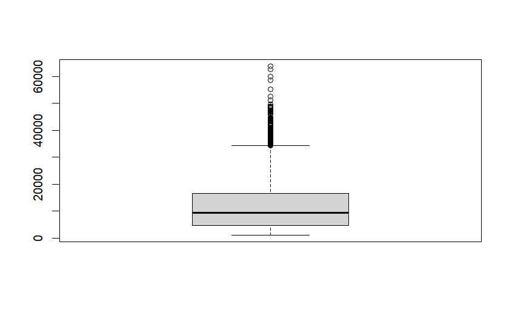

```r
#atributos numéricos o ratio
#visualizar
boxplot(data=meds, meds$charges)
Plot(charges, data=meds, by=sex)
```

Cerrando con la estadística descriptiva, se calculan las medidas de tendencia central para la variable de interés de este estudio, el cual es el costo del seguro médico, empezando por la media y la mediana.

```r
#calcular tendencia central
mean(meds$charges, na.rm = TRUE)
```

```
[1] 13261.37
```

```r
median(meds$charges, na.rm = TRUE)
```

```
[1] 9333.014
```

Finalmente, se calculan medidas de dispersión para la variable de interés. Donde se tiene en primer lugar la Desviación estándar

```r
#calcular dispersion
sd(meds$charges, na.rm = TRUE)
```

```
[1] 12151.77
```

Mínimo

```r
min(meds$charges, na.rm = TRUE)
```

```
[1] 1121.874
```

Máximo

```r
max(meds$charges, na.rm = TRUE)
```

```
[1] 63770.43
```

Rango

```r
range(meds$charges, na.rm = TRUE)
```

```
[1]  1121.874 63770.428
```

y Varianza

```r
var(meds$charges, na.rm = TRUE)
```

```
[1] 147665488
```

```r
#Usar funcion regsubsets del paquete leaps para generar modelos de seleccion de variables
#BEST SUBSET
best_models<-regsubsets(charges~., data = meds, nvmax= 8)
summary(best_models)
```

```
Subset selection object
Call: regsubsets.formula(charges ~ ., data = meds, nvmax = 8)
8 Variables  (and intercept)
                Forced in Forced out
age                 FALSE      FALSE
sexmale             FALSE      FALSE
bmi                 FALSE      FALSE
children            FALSE      FALSE
smokeryes           FALSE      FALSE
regionnorthwest     FALSE      FALSE
regionsoutheast     FALSE      FALSE
regionsouthwest     FALSE      FALSE
1 subsets of each size up to 8
Selection Algorithm: exhaustive
         age sexmale bmi children smokeryes regionnorthwest regionsoutheast
1  ( 1 ) " " " "     " " " "      "*"       " "             " "
2  ( 1 ) "*" " "     " " " "      "*"       " "             " "
3  ( 1 ) "*" " "     "*" " "      "*"       " "             " "
4  ( 1 ) "*" " "     "*" "*"      "*"       " "             " "
5  ( 1 ) "*" " "     "*" "*"      "*"       " "             "*"
6  ( 1 ) "*" " "     "*" "*"      "*"       " "             "*"
7  ( 1 ) "*" " "     "*" "*"      "*"       "*"             "*"
8  ( 1 ) "*" "*"     "*" "*"      "*"       "*"             "*"
         regionsouthwest
1  ( 1 ) " "
2  ( 1 ) " "
3  ( 1 ) " "
4  ( 1 ) " "
5  ( 1 ) " "
6  ( 1 ) "*"
7  ( 1 ) "*"
8  ( 1 ) "*"
```

```r
best_models$rss
```

```
[1] 409181068624 406839261380 406548594398 404589302676 389936539631
[6] 389546135547 388414545455 137161991653 101913438847
```

```r
names(summary(best_models))
```

```
[1] "which"  "rsq"    "rss"    "adjr2"  "cp"     "bic"    "outmat" "obj"
```

```r
model_bst<-summary(best_models)
names(model_bst)
```

```
[1] "which"  "rsq"    "rss"    "adjr2"  "cp"     "bic"    "outmat" "obj"
```

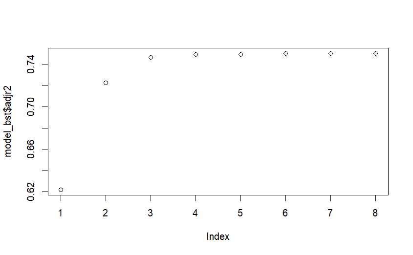

```r
plot(model_bst$adjr2)
```

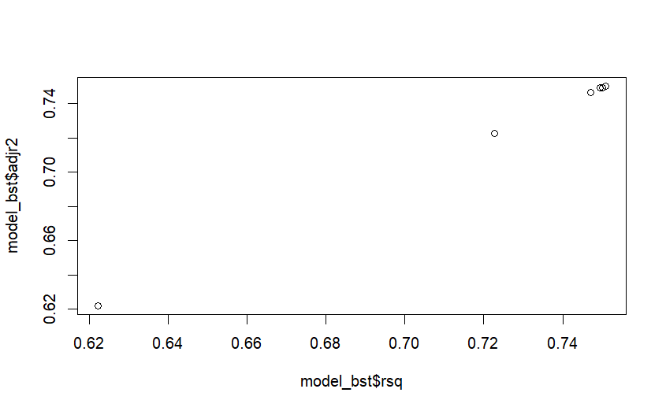

```r
plot(model_bst$rsq,model_bst$adjr2)
```

```r
which.max(model_bst$adjr2)
```

```
[1] 6
```

```r
coef(object = best_models, id = 5)
```

```
    (Intercept)             age             bmi        children       smokeryes
    -11954.6426        255.8434        323.8088        498.4304      23994.7295
regionsoutheast
      -588.0026
```

De los gráficos es posible notar que un modelo con 3 variables es el ideal, pues ofrece el incremento de Rcuadrado, sin agregar mucha complejidad al modelo. Estas 3 variables serían si la persona es o no fumadora, su edad, y su índice de masa corporal.

```r
# Escalar variables
lm_scaled   <-  lm(meds$charges~ meds$age + meds$bmi+ meds$children, data = meds    )
summary(lm_scaled)
```

```
Call:
lm(formula = meds$charges ~ meds$age + meds$bmi + meds$children,
    data = meds)

Residuals:
   Min     1Q Median     3Q    Max
-13919  -7040  -5073   7030  48655

Coefficients:
              Estimate Std. Error t value             Pr(>|t|)
(Intercept)   -6982.71    1220.29  -5.722         0.0000000116 ***
meds$age        239.43      15.49  15.452 < 0.0000000000000002 ***
meds$bmi        334.18      35.57   9.395 < 0.0000000000000002 ***
meds$children   562.86     178.46   3.154              0.00163 **
---
Signif. codes:  0 ‘***’ 0.001 ‘**’ 0.01 ‘*’ 0.05 ‘.’ 0.1 ‘ ’ 1

Residual standard error: 11400 on 2768 degrees of freedom
Multiple R-squared:  0.1203,    Adjusted R-squared:  0.1193
F-statistic: 126.2 on 3 and 2768 DF,  p-value: < 0.00000000000000022
```

```r
anova(lm_scaled)
```

```
Analysis of Variance Table

Response: meds$charges
                Df       Sum Sq     Mean Sq  F value                Pr(>F)
meds$age         1  36489169305 36489169305 280.5885 < 0.00000000000000022 ***
meds$bmi         1  11433347437 11433347437  87.9183 < 0.00000000000000022 ***
meds$children    1   1293665216  1293665216   9.9478              0.001628 **
Residuals     2768 359964886667   130045118
---
Signif. codes:  0 ‘***’ 0.001 ‘**’ 0.01 ‘*’ 0.05 ‘.’ 0.1 ‘ ’ 1
```

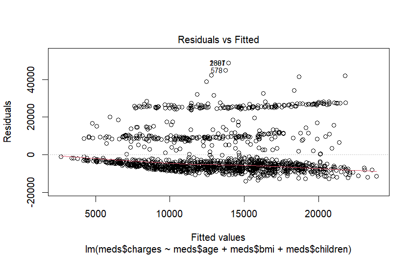

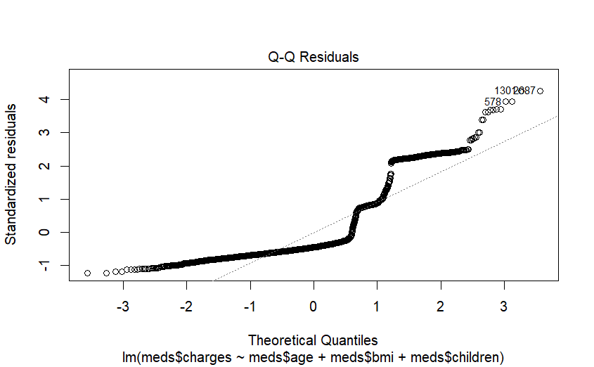

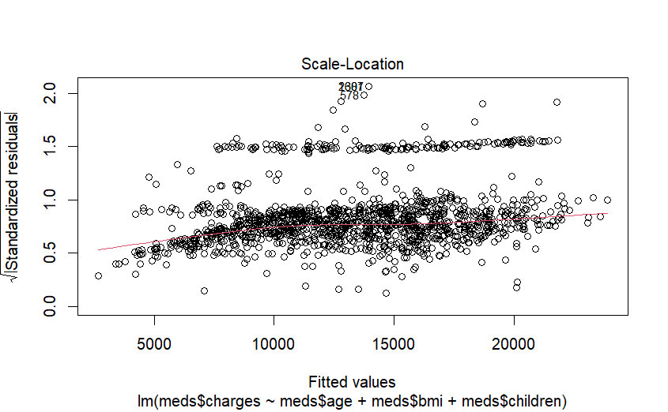

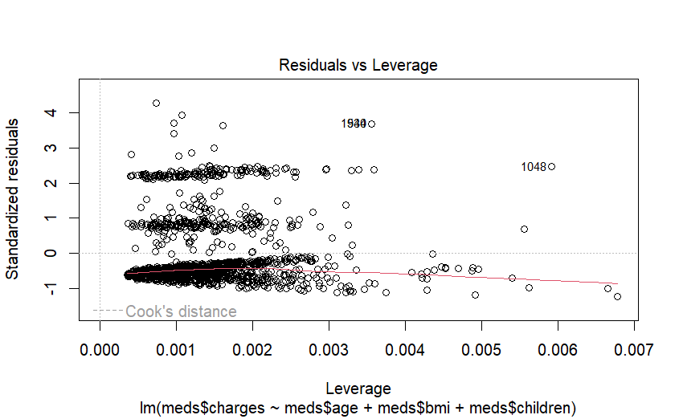

```r
plot(lm_scaled)
```

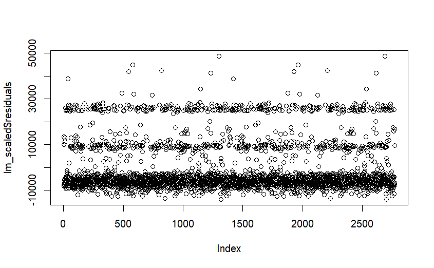

```r
plot(lm_scaled$residuals)
```

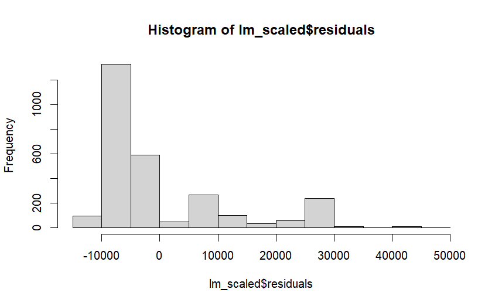

```r
hist(lm_scaled$residuals)
```

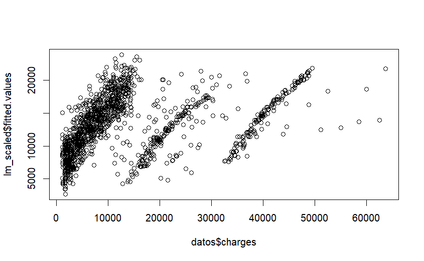

```r
plot(datos$charges,lm_scaled$fitted.values)
```

3. Modelo Predictor:  
   Para esta sección, se utilizó primeramente un muestro aleatorio para determinar los conjuntos de entrenamiento y testeo, seteando así una semilla que permite la reproductibilidad de los resultados

```r
#Muestreo aleatorio

library(tree)
set.seed(17)
train <- sample(1:nrow(meds), size = nrow(meds)*0.5)
```

Una vez creado el conjunto de entrenamiento, se procede a crear el árbol de decisión primigenio utilizando la funcion Mtree

```r
#Creación del árbol de decisión
Mtree <- tree(formula = meds$charges ~ ., data = meds, subset = train, split = "deviance")
summary(Mtree)
```

```
Regression tree:
tree(formula = meds$charges ~ ., data = meds, subset = train,
    split = "deviance")
Variables actually used in tree construction:
[1] "age"      "bmi"      "children"
Number of terminal nodes:  6
Residual mean deviance:  126400000 = 174500000000 / 1380
Distribution of residuals:
   Min. 1st Qu.  Median    Mean 3rd Qu.    Max.
 -18300   -7036   -4204       0    5543   48130
```

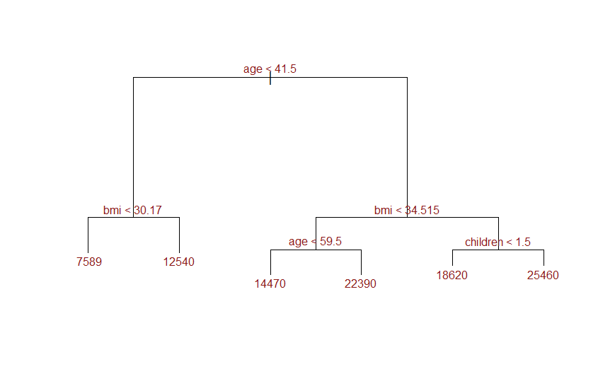

```r
plot(x = Mtree, type = "proportional")
text(x = Mtree, splits = TRUE, pretty = 0, cex = 0.8, col = "firebrick4")
```

```r
#Cross-validation
set.seed(17)
cv_tree <- cv.tree(Mtree, K = 10)
cv_tree
```

```
$size
[1] 6 5 4 3 2 1

$dev
[1] 186711180983 185420871922 186416774629 191401381707 191310329264
[6] 208083702402

$k
[1]        -Inf  2136689370  3329398930  4347482545  4691039991 18832611054

$method
[1] "deviance"

attr(,"class")
[1] "prune"         "tree.sequence"
```

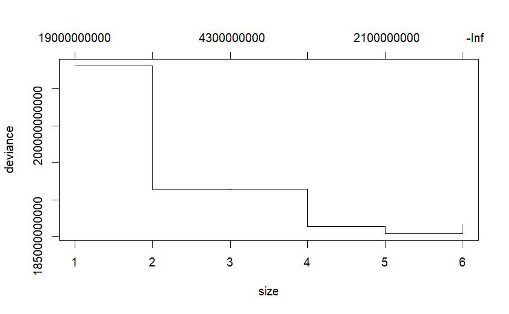

```r
plot(cv_tree)
```

Luego, se procede a diseñar un dataframe con los resultados de la validación cruzada, para luego evaluar estos resultados según la cantidad de nodos y el hiperparámetro alfa de penalización del árbol, para encontrar el tamaño óptimo del árbol

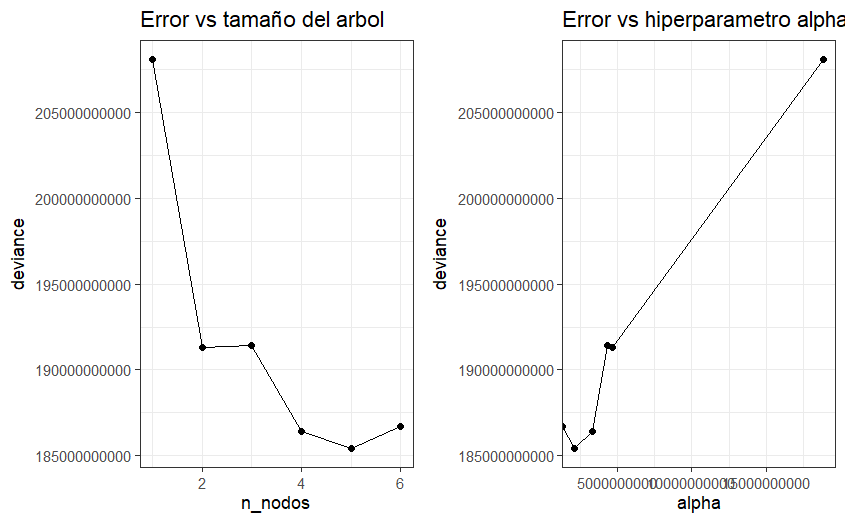

```r
resultados_cv <- data.frame(n_nodos = cv_tree$size, deviance = cv_tree$dev, alpha = cv_tree$k)

p1 <- ggplot(data = resultados_cv, aes(x = n_nodos, y = deviance)) +
  geom_line() + geom_point() +
  labs(title = "Error vs tamaño del arbol") + theme_bw()


p2 <- ggplot(data = resultados_cv, aes(x = alpha, y = deviance)) +
  geom_line() + geom_point() +
  labs(title = "Error vs hiperparametro alpha") + theme_bw()
ggarrange(p1, p2)
```

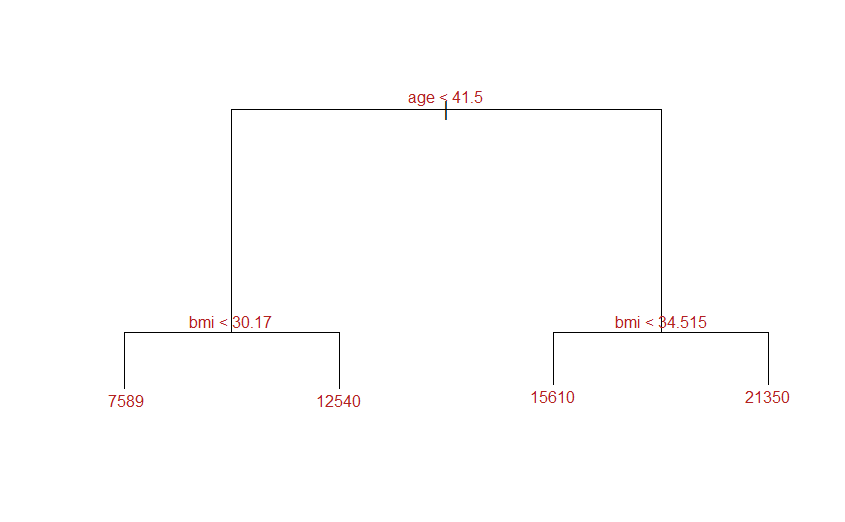

```r
arbol_pruning <- prune.tree(tree = Mtree, best = 4)
plot(x = arbol_pruning, type = "proportional")
text(x = arbol_pruning, splits = TRUE, pretty = 0, cex = 0.8, col = "firebrick")
```

Finalmente, se genera un dataframe que contenga las predicciones del módelo de árbol de decisión definitivo,para luego calcular el “Mean Square Error” como medida con la cual evaluamos el modelo.

```r
#Evaluación del Modelo
predicciones <- predict(arbol_pruning, newdata = meds[-train,])
e<-(predicciones - meds[-train,"charges"])^{2}
e
```

| charges |
| --- |
| 117021993.464707 |
| 65508962.704070 |
| 207230522.228598 |
| 94532.554286 |
| 177253281.750135 |
| 148821417.145687 |
| 732705585.590737 |
| 23156792.590206 |
| 590210304.801769 |
| 130101665.958534 |

[output cut: 990 more lines]

```r
summary(e)
```

```
    charges
 Min.   :         7
 1st Qu.:  19880066
 Median :  51015675
 Mean   : 133697797
 3rd Qu.: 114617169
 Max.   :2207438595
```